# Datová gramotnost (nejen) pro začínající vědce

22. 3. 2022

## Co nás dnes čeká?

1. Popisné statistiky
2. Kauzální inference
3. P-hodnota a replikační krize

## Popisné statistiky

## Statistika je když…

**Efektivita vakcíny Pfizer-BioNTech je 73 %.**

**11,5 % lidí v Česku je ohroženo chudobou.**

## Ohrožení chudobou a sociálním vyloučením

[figure not shown]

[Zdroj Eurostat](https://ec.europa.eu/eurostat/web/products-eurostat-news/-/edn-20211015-1#:~:text=In%202020%2C%20there%20were%2096.5,data%20published%20by%20Eurostat%20today.)

- Jak byste takto nízkou míru ohrožení chudobou u nás vysvětlili?

## Co je ohrožení chudobou a sociálním vyloučením?

> At risk of poverty or social exclusion, abbreviated as AROPE, corresponds to the sum of persons who are either at risk of poverty, or severely materially and socially deprived or living in a household with a very low work intensity.

> Eurostat
- Ale co to znamená?

## Operacionalizace

Překlopení pojmů z jazyka teorie do observačního jazyka.

Chudoba:

1. Metrika (například příjmová chudoba)
2. Hranice chudoby (například 60 % mediánu v dané ekonomice)
3. Agregace

## Základní reprodukční číslo

\[\Huge R_0\]

## Základní představa pro \(R_0 = 2\)

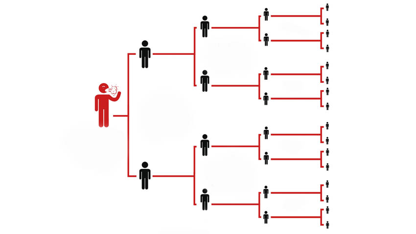

[Zdroj obrázku Michigan Health Lab](https://images.app.goo.gl/qdgNZJQBKTSKWKhM8)

## Blíže skutečnosti (pro \(R_0 = 3\))

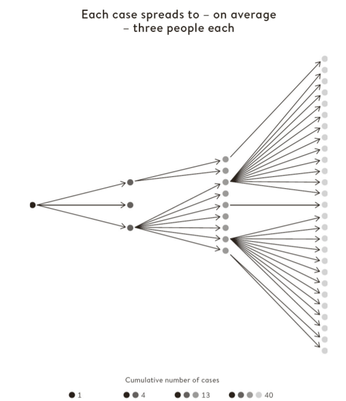

## Odhad rozložení počtu nakažených

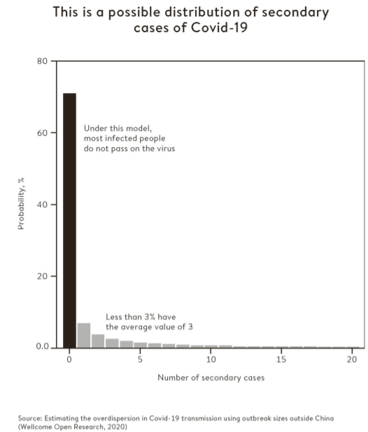

## Přijetí na Univerzitu v Berkeley dle pohlaví

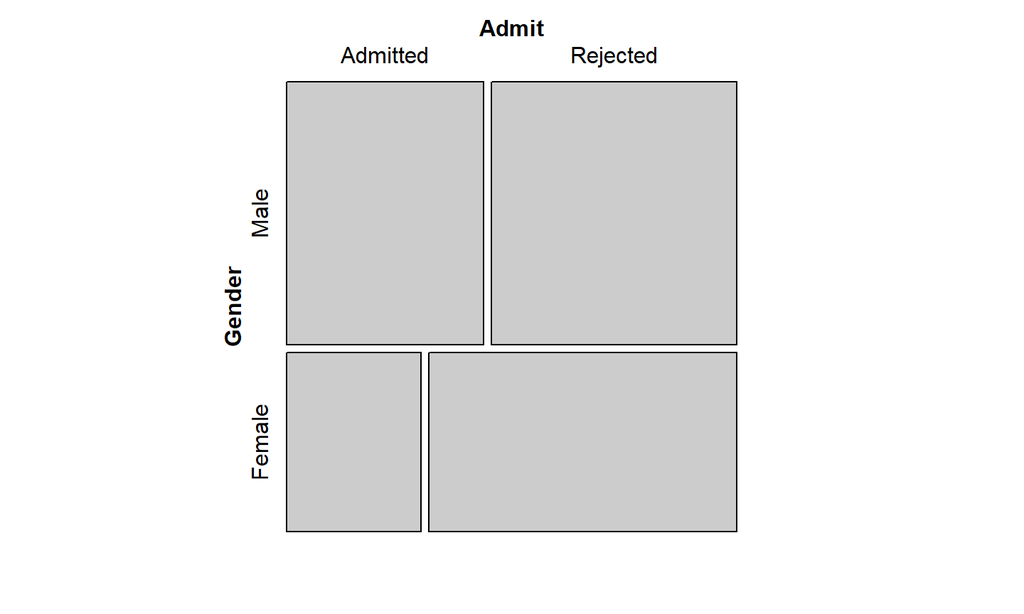

## Zohlednění fakult

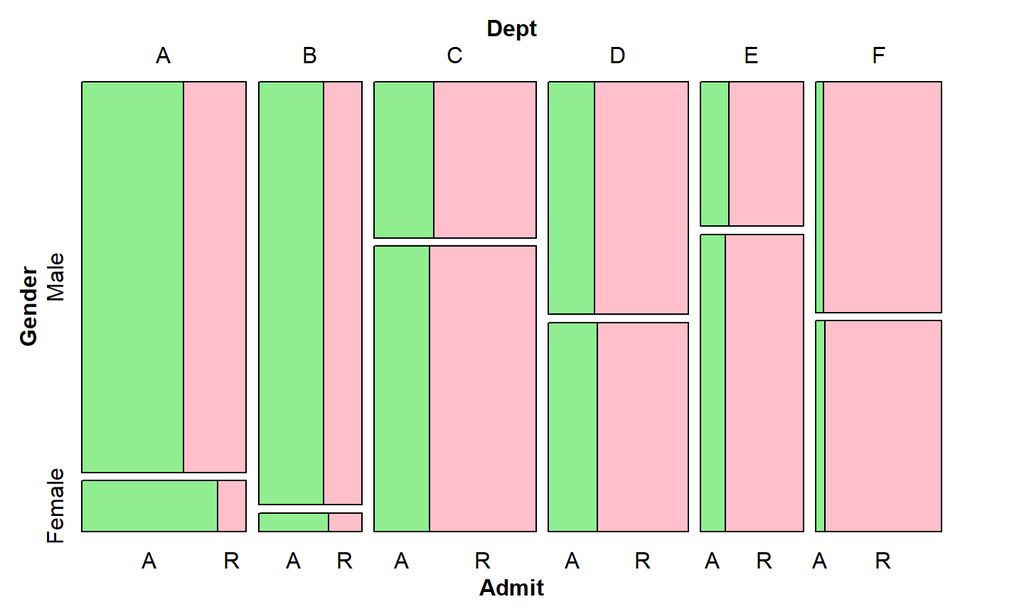

## Obecný problém: Simpsonův paradox

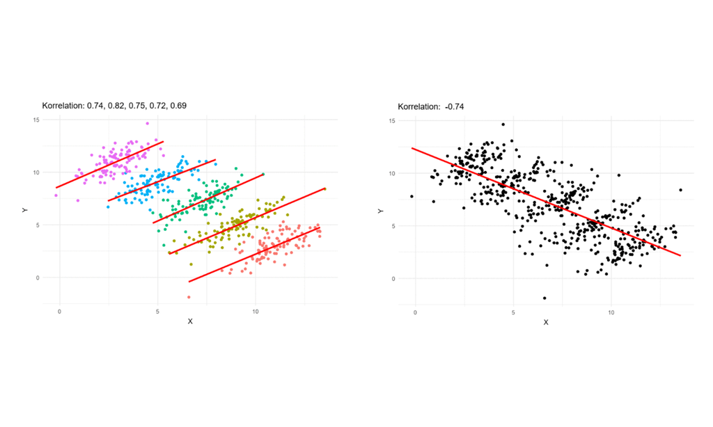

## Co si odnést?

- Nestačí chroustat čísla, je potřeba rozumět tomu, co znamenají. “Avoid premature enumeration.” (T. Harford)
- Operacionalizace je zřídka (pokud vůbec kdy) neutrální. Co a jak sledujeme má implikace pro naše rozhodování.
- Popisná statistika může zastírat mechanismus, který působí v realitě.
- Vztahy na individuální a agregované úrovni mohou být dramaticky odlišné (Simpsonův paradox).

## Kde se začíst?

Skvělá kniha pro rozvoj datové gramotnosti každodenního života je **How to Make the World Add Up** (Harford 2021). Tim Harford je dlouhodobý tvůrce podcastu More or Less (BBC) a jeho příklady jsou strhující, skvěle podané a prakticky užitečné - kniha není psána poraženecky, že nás statistika jen klame, ale pozitivně - co můžeme dělat lépe.

Pokud to chcete vzít ještě více od podlahy a zaměřit se na sebe a svůj postoj ke světu a poznávání, doporučuji knihu **The Scout Mindset** (Galef 2021) postavenou na metafoře dvou myšlenkových nastavení: vojáka a zvěda.

Pokud byste měli chuť si osvěžit úplně základní statistiku netechnickou formou, doporučuji moderní přístup k výuce statistiky jako investigativního procesu **The Art of Statistics** (Spiegelhalter 2019)

## Kauzální inference

## Randomized controlled trial (RCT)

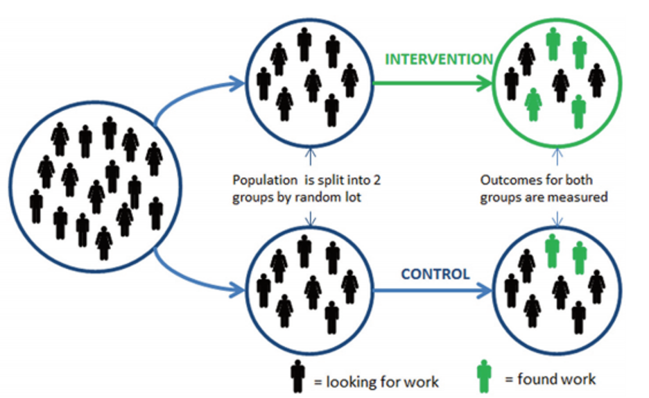

[Haynes a kol., 2012](https://www.gov.uk/government/uploads/system/uploads/attachment_data/file/62529/TLA-1906126.pdf)

## P-hodnota a replikační krize

## Nabízet méně, prodávat více (choice paralysis)

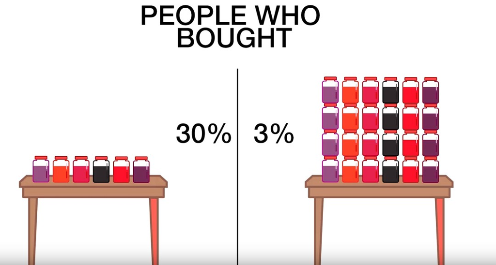

[Obrázek z Medium.com](https://medium.com/@prathameshw95/the-jam-experiment-and-its-effects-in-day-to-day-life-1cec6d03c94e)

## Zkreslení přeživších

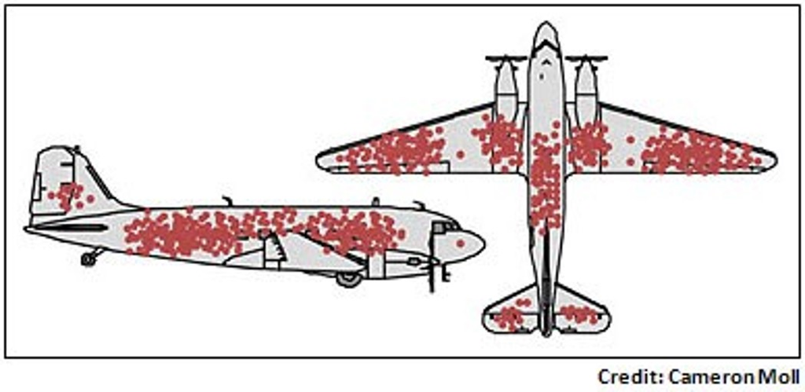

## Pořádné zatřesení

- Daryl Bem: Lidé vidí do budoucnosti (Journal of Personality and Social Psychology, 2011)
- Pokus o replikaci nevyšly, ale časopis je odmítl publikovat

## Publikační zkreslení, replikační krize a Brian Nosek

Nosek shromáždil síť psychologů - replikace 100 studií z respektovaných psychologických časopisů. Jen v 39 případech replikovaly výsledky původních studií.

[Článek o replikaci 100 studií v časopise Science, rok 2015.](https://www.science.org/doi/10.1126/science.aac4716)

## Důvody replikační krize

- Publikační zkreslení
- Malá prestiž replikačního výzkumu
- P-hacking

## P-hacking v podání Derrena Browna

[video not shown]

## Nenápadný p-hacking

- 1024 výzkumníků se pokusí hodit 10krát po sobě pannu
- výzkumníkovi se nepovede experiment, tak ho zahodí a zkusí něco jiného
- výslekdy nejsou statisticky signifikantní,…
  - … ale kdyby se sebralo pár pozorování navíc
  - … ale kdyby se data zanalyzovala po skupinách
  - … ale kdyby se data zanalyzovala jiným modelem
  - … ale kdyby se vyloučila odlehlá pozorování

## HARKing

Hypothesis after results known

## John Ioannidis … na jeho slova došlo

- V roce 2005 publikoval vizionářský článek [“Why Most Published Research Findings Are False”](https://journals.plos.org/plosmedicine/article?id=10.1371/journal.pmed.0020124), kde tuto situaci předpověděl.

## A ne, POWER POSING asi nefunguje

… i když ten Ted Talk má na YouTube 20 miliónů zhlédnutí

[figure not shown]

[Zdroj Wikipedie](https://en.wikipedia.org/wiki/Power_posing)

## Jak z toho ven?

- Pre-registrace. Top lékařské časopisy už jinak ani studie nepublikují (i když své standardy často nedodržují příliš přísně), ostatní obory to pomalu začínají dohánět (a všude to není možné)
- Časopis Trials (medicína) - publikace RCT nezávisle na výsledku a signifikanci.
- Cochrane Collaboration (systematic reviews, medicína)
- Campbell Collaboration (systematic reviews, sociální vědy, vzdělávání)

## Co je p-hodnota?

“Informally, a p-value is the probability under a specified statistical model that a statistical summary of the data (e.g., the sample mean difference between two compared groups) would be equal to or more extreme than its observed value.” (Wasserstein and Lazar 2016)

## Kritika p-hodnoty

- p-hodnota je nevhodně používána jako míra důležitosti výsledku (přitom nulová hypotéza může být zcela banální)
- p-hodnota je používána jako doklad toho, že byl učiněn vědecký objev, při zanedbání mnohem důležitějších kritérií (design studie, kvalita měřícího nástroje, předchozí evidence,…)
- p-hodnota je používána nesprávně (p-hacking)
- p-hodnota je nesprávně interpretována (např. nezamítání nulové hypotézy je vnímáno jako evidence ve prospěch nulové hypotézy)
- obvykle není věcný rozdíl mezi p-hodnotou 5,1 a 4,9

## Další čtení o p-hodnotě

Zásadní text je [vyjádření American Statistical Association](https://amstat.tandfonline.com/doi/full/10.1080/00031305.2016.1154108#.YjeIWOqZO3C). Doporučit lze také [tento blog](http://daniellakens.blogspot.com/2021/11/why-p-values-should-be-interpreted-as-p.html) Daniela Lakense.

## Reference

(Kromě těch, kde jsou v prezentaci přímé prokliky na zdroj.)

Galef, Julia. 2021. *The Scout Mindset: Why Some People See Things Clearly and Others Don’t*. New York: Portfolio.

Harford, Tim. 2021. *How to Make the World Add up: Ten Rules for Thinking Differently about Numbers*. 1st edition. London: The Bridge Street Press.

Iyengar, S. S., and M. R. Lepper. 2000. “When choice is demotivating: can one desire too much of a good thing?” *Journal of Personality and Social Psychology* 79 (6): 995–1006. https://doi.org/10.1037//0022-3514.79.6.995.

Spiegelhalter, David. 2019. *The Art of Statistics: Learning from Data*. UK USA Canada Ireland Australia India New Zealand South Africa: Pelican.

Wasserstein, Ronald L., and Nicole A. Lazar. 2016. “The ASA Statement on p-Values: Context, Process, and Purpose.” *The American Statistician* 70 (2): 129–33. https://doi.org/10.1080/00031305.2016.1154108.